# HW1_S23

Shengyuan Wang

2023-01-23

## Homework 1, due Wednesday 1/25 at 5PM

Homework guidelines:

- Turn in this assignment as a PDF on Moodle, please! To create a PDF, I suggest knitting to HTML, then opening the HTML file in a browser and saving to PDF from there.
- You’re invited to collaborate and discuss with each other, and then each person should turn in their own assignment, which should be their own work. “Discussing” is very different from copying and I trust students to stay on the right side of this line. In general, anything you say out loud to another person is fine, and looking at a screen together (in person or on Zoom) is fine. Sharing files or screenshots is a bad idea. Name the people you work with below (question 0).
- If you start early, you’re giving yourself the chance to ask questions and turn in a polished product. If you start late, you won’t be able to get help as easily.

### Q0: Names

Who did you work with on this assignment? You’ll get a bonus 5 points if you name someone and they name you. *No scores above 100% are allowed, but these bonus points can repair mistakes on this assignment*.

**Solution**:

Name: Wenxuan Zhu

I worked with Wenxuan Zhu on this assignment.

### Q1: Eigenvalues of a symmetric matrix

- Suppose that $A$ is an $n\times n$ matrix and that $x$ is a vector in $\mathbb{R}^n$. Is $x^TAx$ a number, vector, or matrix?

**Solution**:

$x^T$ is a $1 \times n$ vector, $A$ is a $n \times n$ matrix, $x$ is a $n \times 1$ vector. So when they time together, the result $x^TAx$ will be a number.

- Suppose that $Ax = \lambda x$ and $A = A^T$ and $x$ is not all zeros; that is, $\lambda$ is an eigenvector of a symmetric matrix $A$ with eigenvalue $\lambda$. Show that $x^TAx = \lambda x^Tx$. Explain why this means that $\lambda$ must be a real number.

**Solution**:

Since $A$ is real, $\overline{A} = A$, $\overline{A}$ here is the element-wise complex conjugate.
$$A\overline{x} =
\overline{\lambda}\overline{x}$$
Then, we can transpose both side and we will get
$$\overline{x}^{T}A =
\overline{\lambda}\overline{x}^{T}$$
So, we can get
$$\overline{\lambda}\overline{x}^{T}x =
\overline{x}^{T}Ax = \overline{x}^{T}\lambda x=\lambda
\overline{x}^{T}x$$
Since $x \neq 0$,
$$\overline{x}^{T}x =
\overline{x}_{1} \cdot x_{1} + \overline{x}_{2} \cdot x_{2} + \cdots
+ \overline{x}_{n} \cdot x_{n} > 0$$
So, we can get $\overline{\lambda} = \lambda$ from $\overline{\lambda}\overline{x}^{T}x = \lambda \overline{x}^{T}x$, which means $\lambda$ is real.

- Form the matrices $P$ and $S$ in R and use the syntax *eigen(A)$values* to find their eigenvalues. (According to the result we proved, $S$ should have real eigenvalues and $P$ might or might not have real eigenvalues).
  $$P =
  \begin{pmatrix} -4&5&6\\1&0&9
  \\9&1&2\end{pmatrix}
  \qquad
  S = \begin{pmatrix}
  -1&2&1\\2&7&-3\\1&-3&4\end{pmatrix}$$

**Solution**:

```r
P <- matrix(c(-4, 1, 9, 5, 0, 1, 6, 9, 2), nrow = 3, ncol = 3)
P
```

```
##      [,1] [,2] [,3]
## [1,]   -4    5    6
## [2,]    1    0    9
## [3,]    9    1    2
```

```r
S <- matrix(c(-1, 2, 1, 2, 7, -3, 1, -3, 4), nrow = 3, ncol = 3)
S
```

```
##      [,1] [,2] [,3]
## [1,]   -1    2    1
## [2,]    2    7   -3
## [3,]    1   -3    4
```

```r
eigen(S)$values
```

```
## [1]  8.999999999999998  3.000000000000006 -1.999999999999996
```

```r
eigen(P)$values
```

```
## [1]  9.988620673572962+0.00000000000000i -5.994310336786480+2.79607365674972i
## [3] -5.994310336786480-2.79607365674972i
```

### Q2: Nearly R-O

Write some code to create and print out this matrix (it’s possible to do it in two lines, but any solution is fine as long as you don’t separately type all 16 entries). Explain why it is nearly a R-O matrix, where “R-O” stands for something on our first-day slides.
$$A = \begin{pmatrix}
1&3&5&10\\
10&30&50&100\\
-2&-6&-10&-20\\
100&300&4&4
\end{pmatrix}$$

**Solution**:

```r
x <- c(1, 10, -2, 100)
A <- matrix(c(x, 3*x, 5*x, 10*x), nrow = 4, ncol = 4)
A[4, 3:4] <- 4
A
```

```
##      [,1] [,2] [,3] [,4]
## [1,]    1    3    5   10
## [2,]   10   30   50  100
## [3,]   -2   -6  -10  -20
## [4,]  100  300    4    4
```

It is nearly a rank one matrix because after we change $A_{43}$ to 500, $A_{44}$ to 1000, each column of the matrix is the multiple of the first column.

### Q3: Basic graph example

Write some code to plot the quadratic function $y=x^2 - 5x + 2$. Make sure that the minimum is visible inside your figure.

**Solution**:

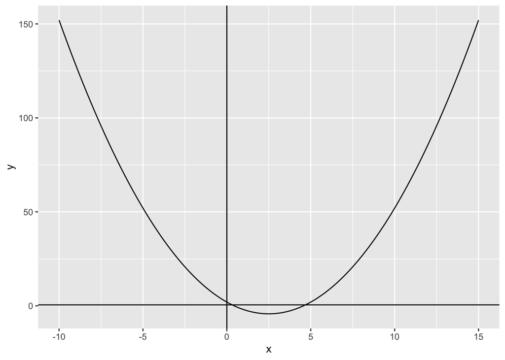

```r
library(ggplot2)


sigmoid <- function(x) x**2-5*x+2
x<-seq(-10, 15, by=0.01)
y<-sigmoid(x)
df<-data.frame(x, y)

g <- ggplot(df, aes(x,y)) +
  geom_line(col='black') +
  geom_hline(yintercept = 0.5) +
  geom_vline(xintercept = 0)
g
```

### Q4: When power functions look linear

Comment carefully on the differences you see between the three versions. Then explain why a function of the form $y = x^p$ looks linear on a log-log plot. *Hint: let $w = \log_{10}(y)$ and let $t = \log_{10}(x)$, then show that there is a linear relationship between $t$ and $w$.*

**Solution**:

In the second version, we manually change the x-axis and y-axis into $log_{10}(x)$ and $log_{10}(y)$, the plot shows the fucntion $y = -2x$. In this plot, the X range is also from 1 to 1000, in other words, $log_{10}(x)$ ranges from 0 to 3, and $log_{10}(y)$ ranges from -6 to 0.

In the third version, we can see although it looks like the same as the second plot, however, this plot does not show the funtion $y=-2x$, instead it shows $y = x^{-2}$. The reason it looks similar to the second one is that both the axises are all logarithmic through the code “log=‘xy’”, it exists dramatic difference in the x-axis and y-axis.

**Proof:**

Let $w= log_{10}(y)$, $t=log_{10}(x)$.

We can get
$$y = x^{p} = (10^{t})^{p} =
10^{tp} = 10^{w}$$
Thus, $w = tp$, which is a linear relationship between $w$ and $t$.

### Q5: Create a letter

As on the Day 1 activity, create a color image showing the first letter of your name by building appropriate matrices in R. Give it a white background (initialize the matrices with 1’s instead of 0’s). Add it to the Google Doc, and also include it here.

**Solution**:

```r
library('magick')
```

```
## # A tibble: 1 × 7
##   format width height colorspace matte filesize density
##   <chr>  <int>  <int> <chr>      <lgl>    <int> <chr>
## 1 PNG      500    500 sRGB       FALSE        0 72x72
```

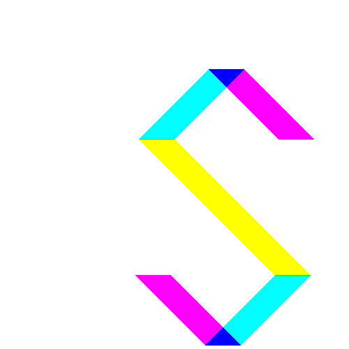

```r
myRed <- matrix(1,500,500) # a 500x500 grid of zeros
myRed[0:500,0:500] <- 1 # change some entries into ones

myGreen <- matrix(1,500,500)
myBlue <- matrix(1,500,500)
shiftleft <- 100
shiftDown <- 100
for (x in 0 : 100) {
  for (t in 0 : 50) {
    t <- t - shiftleft
    myGreen[x+shiftDown, 400+x+t] <- 0
    myRed[x+shiftDown, 400-x+t] <- 0
    myBlue[100+x+shiftDown, 300+x+t] <- 0
    myBlue[195+x+shiftDown, 395+x+t] <- 0
    myRed[395-x+shiftDown, 395+x+t] <- 0
    myGreen[395-x+shiftDown, 395-x+t] <- 0
  }

}
data <- array(c(myRed,myGreen,myBlue),dim = c(500,500,3))

im <- image_read(data)
print(im) # this displays the image in RStudio and knitted documents
```

```r
image_write(im,"mycolors.png")
```

### Q6: High contrast image

The image “Department.png” is a cropped version of a photo by Stefani Reynolds in a January 2023 article about the upcoming US debt ceiling crisis in the New York Times. It shows part of the Treasury Department building in Washington. It is a color image, but it looks pretty gray because for most pixels, the values in the R, G, and B channels are all close together. Save the image in the same folder as your main RMD file and then uncomment these lines to see it:

```
## # A tibble: 1 × 7
##   format width height colorspace matte filesize density
##   <chr>  <int>  <int> <chr>      <lgl>    <int> <chr>
## 1 PNG      370    382 sRGB       FALSE   247388 57x57
```

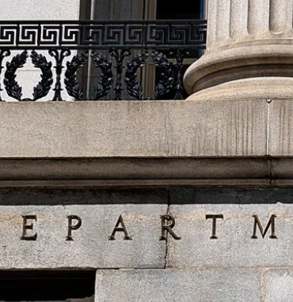

```r
library("magick")
a = image_read("Department.png")
A = as.integer(a[[1]])/256
redA = A[,,1]
greenA = A[,,2]
blueA = A[,,3]
print(a) # this displays the image in RStudio and knitted documents
```

We will make a high-contrast version of this image using a new code trick: updating a matrix or vector using conditional tests.

Here is a first example where we create a vector and then ask which entries are less than 5:

```r
v <- 1:8
print(v)
```

```
## [1] 1 2 3 4 5 6 7 8
```

```r
print(v < 5)
```

```
## [1]  TRUE  TRUE  TRUE  TRUE FALSE FALSE FALSE FALSE
```

The useful trick is that you can update the entries for which the condition is true:

```r
v[v<5] <- -1
print(v)
```

```
## [1] -1 -1 -1 -1  5  6  7  8
```

The same trick works for matrices and high-dimensional arrays:

```r
a <- matrix(rnorm(12),3,4) # create a 3x4 matrix with normally distributed entries
a[a<0] <- 0 # set all negative elements to be zero
print(a) # we should see about half zeros, half positive numbers
```

```
##                    [,1]               [,2]                [,3] [,4]
## [1,] 0.0000000000000000 1.0494480754698172 0.08583875131737073    0
## [2,] 0.0000000000000000 0.2069218557851729 0.00000000000000000    0
## [3,] 0.5290418219930683 0.0000000000000000 0.00000000000000000    0
```

The three matrices redA, greenA, and blueA contain numbers between 0 and 1. Pick a cutoff between 0 and 1 (0.5 is a good choice but you can experiment) and then set all entries to 1 if they’re greater than the cutoff, or 0 otherwise. Then display the altered image, the “high contrast” version. It should be mostly black-and-white but there will be some colored pixels - explain why.

**Solution**:

```
## # A tibble: 1 × 7
##   format width height colorspace matte filesize density
##   <chr>  <int>  <int> <chr>      <lgl>    <int> <chr>
## 1 PNG      370    382 sRGB       FALSE        0 72x72
```

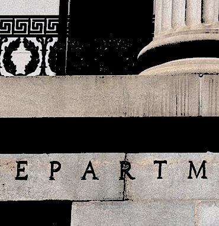

```r
library("magick")
A[redA < 0.4] <- 0
A[blueA<0.4] <- 0
A[greenA<0.4] <- 0
hc <- image_read(A)
print(hc)
```